# eda-more-technical

### Libs

```python
import numpy as np
import pandas as pd
import seaborn as sns
import matplotlib.gridspec as gridspec
import matplotlib.pyplot as plt
import matplotlib.style as style

from scipy.stats import skew
from scipy.special import boxcox1p
from scipy.stats import boxcox_normmax
import scipy.stats as stats

from datetime import datetime

from sklearn.linear_model import ElasticNetCV, LassoCV, RidgeCV, LinearRegression, Ridge, Lasso, ElasticNet
from sklearn.ensemble import GradientBoostingRegressor
from sklearn.svm import SVR
from mlxtend.regressor import StackingCVRegressor
from xgboost import XGBRegressor
from lightgbm import LGBMRegressor
import xgboost as xg
import sklearn.linear_model as linear_model
from sklearn.cluster import KMeans
from sklearn.manifold import TSNE
from sklearn.decomposition import PCA

from sklearn.pipeline import make_pipeline
from sklearn.preprocessing import RobustScaler
from sklearn.preprocessing import StandardScaler
from sklearn.model_selection import KFold, cross_val_score, train_test_split, StratifiedKFold
from sklearn.metrics import mean_squared_error, mean_absolute_error

import missingno as msno
# !pip install optuna
# import optuna
# !pip install pandas-profiling==2.7.1
import pandas_profiling as pp
```

```python
import warnings
warnings.filterwarnings('ignore')
```

```python
train = pd.read_csv('/content/drive/MyDrive/Colab Notebooks/Kaggle_/Regression_/House_price/train.csv')
test = pd.read_csv('/content/drive/MyDrive/Colab Notebooks/Kaggle_/Regression_/House_price/test.csv')
print(train.shape, test.shape)
```

```
(1460, 81) (1459, 80)
```

```python
# pp.ProfileReport(train)
```

```python
train.head(10)
```

|  | Id | MSSubClass | MSZoning | LotFrontage | LotArea | Street | Alley | LotShape | LandContour | Utilities | LotConfig | LandSlope | Neighborhood | Condition1 | Condition2 | BldgType | HouseStyle | OverallQual | OverallCond | YearBuilt | YearRemodAdd | RoofStyle | RoofMatl | Exterior1st | Exterior2nd | MasVnrType | MasVnrArea | ExterQual | ExterCond | … |
| --- | --- | --- | --- | --- | --- | --- | --- | --- | --- | --- | --- | --- | --- | --- | --- | --- | --- | --- | --- | --- | --- | --- | --- | --- | --- | --- | --- | --- | --- | --- |
| 0 | 1 | 60 | RL | 65.0 | 8450 | Pave | NaN | Reg | Lvl | AllPub | Inside | Gtl | CollgCr | Norm | Norm | 1Fam | 2Story | 7 | 5 | 2003 | 2003 | Gable | CompShg | VinylSd | VinylSd | BrkFace | 196.0 | Gd | TA | … |
| 1 | 2 | 20 | RL | 80.0 | 9600 | Pave | NaN | Reg | Lvl | AllPub | FR2 | Gtl | Veenker | Feedr | Norm | 1Fam | 1Story | 6 | 8 | 1976 | 1976 | Gable | CompShg | MetalSd | MetalSd | None | 0.0 | TA | TA | … |
| 2 | 3 | 60 | RL | 68.0 | 11250 | Pave | NaN | IR1 | Lvl | AllPub | Inside | Gtl | CollgCr | Norm | Norm | 1Fam | 2Story | 7 | 5 | 2001 | 2002 | Gable | CompShg | VinylSd | VinylSd | BrkFace | 162.0 | Gd | TA | … |
| 3 | 4 | 70 | RL | 60.0 | 9550 | Pave | NaN | IR1 | Lvl | AllPub | Corner | Gtl | Crawfor | Norm | Norm | 1Fam | 2Story | 7 | 5 | 1915 | 1970 | Gable | CompShg | Wd Sdng | Wd Shng | None | 0.0 | TA | TA | … |
| 4 | 5 | 60 | RL | 84.0 | 14260 | Pave | NaN | IR1 | Lvl | AllPub | FR2 | Gtl | NoRidge | Norm | Norm | 1Fam | 2Story | 8 | 5 | 2000 | 2000 | Gable | CompShg | VinylSd | VinylSd | BrkFace | 350.0 | Gd | TA | … |
| 5 | 6 | 50 | RL | 85.0 | 14115 | Pave | NaN | IR1 | Lvl | AllPub | Inside | Gtl | Mitchel | Norm | Norm | 1Fam | 1.5Fin | 5 | 5 | 1993 | 1995 | Gable | CompShg | VinylSd | VinylSd | None | 0.0 | TA | TA | … |
| 6 | 7 | 20 | RL | 75.0 | 10084 | Pave | NaN | Reg | Lvl | AllPub | Inside | Gtl | Somerst | Norm | Norm | 1Fam | 1Story | 8 | 5 | 2004 | 2005 | Gable | CompShg | VinylSd | VinylSd | Stone | 186.0 | Gd | TA | … |
| 7 | 8 | 60 | RL | NaN | 10382 | Pave | NaN | IR1 | Lvl | AllPub | Corner | Gtl | NWAmes | PosN | Norm | 1Fam | 2Story | 7 | 6 | 1973 | 1973 | Gable | CompShg | HdBoard | HdBoard | Stone | 240.0 | TA | TA | … |
| 8 | 9 | 50 | RM | 51.0 | 6120 | Pave | NaN | Reg | Lvl | AllPub | Inside | Gtl | OldTown | Artery | Norm | 1Fam | 1.5Fin | 7 | 5 | 1931 | 1950 | Gable | CompShg | BrkFace | Wd Shng | None | 0.0 | TA | TA | … |
| 9 | 10 | 190 | RL | 50.0 | 7420 | Pave | NaN | Reg | Lvl | AllPub | Corner | Gtl | BrkSide | Artery | Artery | 2fmCon | 1.5Unf | 5 | 6 | 1939 | 1950 | Gable | CompShg | MetalSd | MetalSd | None | 0.0 | TA | TA | … |

10 rows × 81 columns

```python
train.describe().T
```

|  | count | mean | std | min | 25% | 50% | 75% | max |
| --- | --- | --- | --- | --- | --- | --- | --- | --- |
| Id | 1460.0 | 730.500000 | 421.610009 | 1.0 | 365.75 | 730.5 | 1095.25 | 1460.0 |
| MSSubClass | 1460.0 | 56.897260 | 42.300571 | 20.0 | 20.00 | 50.0 | 70.00 | 190.0 |
| LotFrontage | 1201.0 | 70.049958 | 24.284752 | 21.0 | 59.00 | 69.0 | 80.00 | 313.0 |
| LotArea | 1460.0 | 10516.828082 | 9981.264932 | 1300.0 | 7553.50 | 9478.5 | 11601.50 | 215245.0 |
| OverallQual | 1460.0 | 6.099315 | 1.382997 | 1.0 | 5.00 | 6.0 | 7.00 | 10.0 |
| OverallCond | 1460.0 | 5.575342 | 1.112799 | 1.0 | 5.00 | 5.0 | 6.00 | 9.0 |
| YearBuilt | 1460.0 | 1971.267808 | 30.202904 | 1872.0 | 1954.00 | 1973.0 | 2000.00 | 2010.0 |
| YearRemodAdd | 1460.0 | 1984.865753 | 20.645407 | 1950.0 | 1967.00 | 1994.0 | 2004.00 | 2010.0 |
| MasVnrArea | 1452.0 | 103.685262 | 181.066207 | 0.0 | 0.00 | 0.0 | 166.00 | 1600.0 |
| BsmtFinSF1 | 1460.0 | 443.639726 | 456.098091 | 0.0 | 0.00 | 383.5 | 712.25 | 5644.0 |
| BsmtFinSF2 | 1460.0 | 46.549315 | 161.319273 | 0.0 | 0.00 | 0.0 | 0.00 | 1474.0 |
| BsmtUnfSF | 1460.0 | 567.240411 | 441.866955 | 0.0 | 223.00 | 477.5 | 808.00 | 2336.0 |
| TotalBsmtSF | 1460.0 | 1057.429452 | 438.705324 | 0.0 | 795.75 | 991.5 | 1298.25 | 6110.0 |
| 1stFlrSF | 1460.0 | 1162.626712 | 386.587738 | 334.0 | 882.00 | 1087.0 | 1391.25 | 4692.0 |
| 2ndFlrSF | 1460.0 | 346.992466 | 436.528436 | 0.0 | 0.00 | 0.0 | 728.00 | 2065.0 |
| LowQualFinSF | 1460.0 | 5.844521 | 48.623081 | 0.0 | 0.00 | 0.0 | 0.00 | 572.0 |
| GrLivArea | 1460.0 | 1515.463699 | 525.480383 | 334.0 | 1129.50 | 1464.0 | 1776.75 | 5642.0 |
| BsmtFullBath | 1460.0 | 0.425342 | 0.518911 | 0.0 | 0.00 | 0.0 | 1.00 | 3.0 |
| BsmtHalfBath | 1460.0 | 0.057534 | 0.238753 | 0.0 | 0.00 | 0.0 | 0.00 | 2.0 |
| FullBath | 1460.0 | 1.565068 | 0.550916 | 0.0 | 1.00 | 2.0 | 2.00 | 3.0 |
| HalfBath | 1460.0 | 0.382877 | 0.502885 | 0.0 | 0.00 | 0.0 | 1.00 | 2.0 |
| BedroomAbvGr | 1460.0 | 2.866438 | 0.815778 | 0.0 | 2.00 | 3.0 | 3.00 | 8.0 |
| KitchenAbvGr | 1460.0 | 1.046575 | 0.220338 | 0.0 | 1.00 | 1.0 | 1.00 | 3.0 |
| TotRmsAbvGrd | 1460.0 | 6.517808 | 1.625393 | 2.0 | 5.00 | 6.0 | 7.00 | 14.0 |
| Fireplaces | 1460.0 | 0.613014 | 0.644666 | 0.0 | 0.00 | 1.0 | 1.00 | 3.0 |
| GarageYrBlt | 1379.0 | 1978.506164 | 24.689725 | 1900.0 | 1961.00 | 1980.0 | 2002.00 | 2010.0 |
| GarageCars | 1460.0 | 1.767123 | 0.747315 | 0.0 | 1.00 | 2.0 | 2.00 | 4.0 |
| GarageArea | 1460.0 | 472.980137 | 213.804841 | 0.0 | 334.50 | 480.0 | 576.00 | 1418.0 |
| WoodDeckSF | 1460.0 | 94.244521 | 125.338794 | 0.0 | 0.00 | 0.0 | 168.00 | 857.0 |
| OpenPorchSF | 1460.0 | 46.660274 | 66.256028 | 0.0 | 0.00 | 25.0 | 68.00 | 547.0 |
| EnclosedPorch | 1460.0 | 21.954110 | 61.119149 | 0.0 | 0.00 | 0.0 | 0.00 | 552.0 |
| 3SsnPorch | 1460.0 | 3.409589 | 29.317331 | 0.0 | 0.00 | 0.0 | 0.00 | 508.0 |
| ScreenPorch | 1460.0 | 15.060959 | 55.757415 | 0.0 | 0.00 | 0.0 | 0.00 | 480.0 |
| PoolArea | 1460.0 | 2.758904 | 40.177307 | 0.0 | 0.00 | 0.0 | 0.00 | 738.0 |
| MiscVal | 1460.0 | 43.489041 | 496.123024 | 0.0 | 0.00 | 0.0 | 0.00 | 15500.0 |
| MoSold | 1460.0 | 6.321918 | 2.703626 | 1.0 | 5.00 | 6.0 | 8.00 | 12.0 |
| YrSold | 1460.0 | 2007.815753 | 1.328095 | 2006.0 | 2007.00 | 2008.0 | 2009.00 | 2010.0 |
| SalePrice | 1460.0 | 180921.195890 | 79442.502883 | 34900.0 | 129975.00 | 163000.0 | 214000.00 | 755000.0 |

```python
train.info()
```

```
<class 'pandas.core.frame.DataFrame'>
RangeIndex: 1460 entries, 0 to 1459
Data columns (total 81 columns):
 #   Column         Non-Null Count  Dtype
---  ------         --------------  -----
 0   Id             1460 non-null   int64
 1   MSSubClass     1460 non-null   int64
 2   MSZoning       1460 non-null   object
 3   LotFrontage    1201 non-null   float64
 4   LotArea        1460 non-null   int64
 5   Street         1460 non-null   object
 6   Alley          91 non-null     object
 7   LotShape       1460 non-null   object
 8   LandContour    1460 non-null   object
 9   Utilities      1460 non-null   object
```

[output cut: 73 more lines]

```python
train.dtypes.value_counts()
```

```
object     43
int64      35
float64     3
dtype: int64
```

### Missing Train values

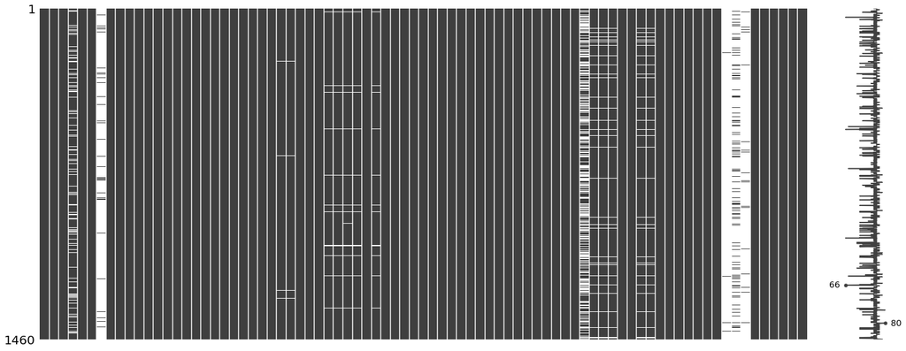

```python
msno.matrix(train);
```

```python
total = train.isnull().sum().sort_values(ascending = False)[train.isnull().sum().sort_values(ascending = False) != 0]
percent = (train.isnull().sum() / train.isnull().count()).sort_values(ascending = False)[(train.isnull().sum() / train.isnull().count()).sort_values(ascending = False) != 0]
missing = pd.concat([total, percent], axis = 1, keys = ['Total', 'Percent'])
print(missing)
```

```
              Total   Percent
PoolQC         1453  0.995205
MiscFeature    1406  0.963014
Alley          1369  0.937671
Fence          1179  0.807534
FireplaceQu     690  0.472603
LotFrontage     259  0.177397
GarageCond       81  0.055479
GarageType       81  0.055479
GarageYrBlt      81  0.055479
GarageFinish     81  0.055479
GarageQual       81  0.055479
BsmtExposure     38  0.026027
BsmtFinType2     38  0.026027
BsmtFinType1     37  0.025342
BsmtCond         37  0.025342
BsmtQual         37  0.025342
MasVnrArea        8  0.005479
MasVnrType        8  0.005479
Electrical        1  0.000685
```

```python
def plotting_3_chart(df, feature):
    style.use("fivethirtyeight")

    fig = plt.figure(constrained_layout = True, figsize = (15, 8))#constrained_layout:auto adjust object placement.
    grid = gridspec.GridSpec(ncols = 3, nrows = 2, figure = fig)

    #Histogram
    ax1 = fig.add_subplot(grid[0, :2])
    ax1.set_title('Histogram')
    sns.distplot(df.loc[:, feature], norm_hist = True, ax = ax1, color = 'g')

    #Probability Plot
    ax2 = fig.add_subplot(grid[1, :2])
    ax2.set_title('Probability Plot')
    stats.probplot(df.loc[:, feature], plot = ax2)

    #Box Plot
    ax3 = fig.add_subplot(grid[:, 2])
    ax3.set_title('Box Plot')
    sns.boxplot(df.loc[:, feature], orient = 'v', ax = ax3)
```

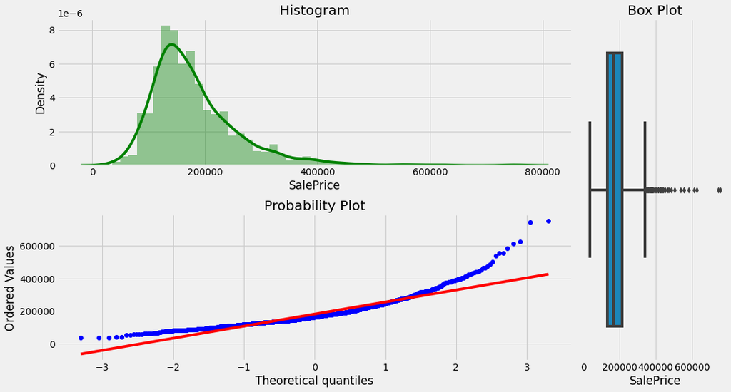

```python
plotting_3_chart(train, 'SalePrice')
```

- Out target variable, **SalePrice** is not normally distributed.
- Our target variable is right-skewed.
- There are multiple outliers in the variable.

It looks like there are quite a bit Skewness and Kurtosis in the target variable. Let's talk about those a bit.

**Skewness**

- is the degree of distortion from the symmetrical bell curve or the normal curve.
- So, a symmetrical distribution will have a skewness of "0".
- There are two types of Skewness: **Positive and Negative.**
- **Positive Skewness**(similar to our target variable distribution) means the tail on the right side of the distribution is longer and fatter.
- In **positive Skewness** the mean and median will be greater than the mode similar to this dataset. Which means more houses were sold by less than the average price.
- **Negative Skewness** means the tail on the left side of the distribution is longer and fatter.
- In **negative Skewness** the mean and median will be less than the mode.
- Skewness differentiates in extreme values in one versus the other tail.

Here is a picture to make more sense.

[figure not shown]

```python
print("Skewness: ", train['SalePrice'].skew())
```

```
Skewness:  1.8828757597682129
```

**Kurtosis**

According to Wikipedia,

*In probability theory and statistics, **Kurtosis** is the measure of the "tailedness" of the probability. distribution of a real-valued random variable.* So, In other words, **it is the measure of the extreme values(outliers) present in the distribution.**

- There are three types of Kurtosis: **Mesokurtic, Leptokurtic, and Platykurtic**.
- Mesokurtic is similar to the normal curve with the standard value of 3. This means that the extreme values of this distribution are similar to that of a normal distribution.
- Leptokurtic: Example of leptokurtic distributions are the T-distributions with small degrees of freedom.
- Platykurtic: Platykurtic describes a particular statistical distribution with thinner tails than a normal distribution. Because this distribution has thin tails, it has fewer outliers (e.g., extreme values three or more standard deviations from the mean) than do mesokurtic and leptokurtic distributions.

[figure not shown]

You can read more about this from [this](https://codeburst.io/2-important-statistics-terms-you-need-to-know-in-data-science-skewness-and-kurtosis-388fef94eeaa) article.

```python
print('kurtosis: ', train['SalePrice'].kurt())
```

```
kurtosis:  6.536281860064529
```

We can fix this by using different types of transformation(more on this later). However, before doing that, I want to find out the relationships among the target variable and other predictor variables. Let's find out.

```python
(train.corr()**2)['SalePrice'].sort_values(ascending = False)#.index[:5]
```

```
SalePrice        1.000000
OverallQual      0.625652
GrLivArea        0.502149
GarageCars       0.410124
GarageArea       0.388667
TotalBsmtSF      0.376481
1stFlrSF         0.367057
FullBath         0.314344
TotRmsAbvGrd     0.284860
YearBuilt        0.273422
YearRemodAdd     0.257151
GarageYrBlt      0.236548
MasVnrArea       0.228000
Fireplaces       0.218023
BsmtFinSF1       0.149320
LotFrontage      0.123763
WoodDeckSF       0.105244
2ndFlrSF         0.101974
OpenPorchSF      0.099765
HalfBath         0.080717
LotArea          0.069613
BsmtFullBath     0.051585
BsmtUnfSF        0.046001
BedroomAbvGr     0.028296
KitchenAbvGr     0.018471
EnclosedPorch    0.016532
ScreenPorch      0.012420
PoolArea         0.008538
MSSubClass       0.007104
OverallCond      0.006062
MoSold           0.002156
3SsnPorch        0.001988
YrSold           0.000837
LowQualFinSF     0.000656
Id               0.000480
MiscVal          0.000449
BsmtHalfBath     0.000284
BsmtFinSF2       0.000129
Name: SalePrice, dtype: float64
```

These are the predictor variables sorted in a descending order starting with the most correlated one **OverallQual**.  
Let's put these in a scatter plot and check how it looks.

#### SalePrice vs OverallQual

```python
def customized_scatterplot(y, x):
    style.use('fivethirtyeight')
    plt.subplots(figsize = (12, 8))
    sns.scatterplot(y = y, x = x)
```

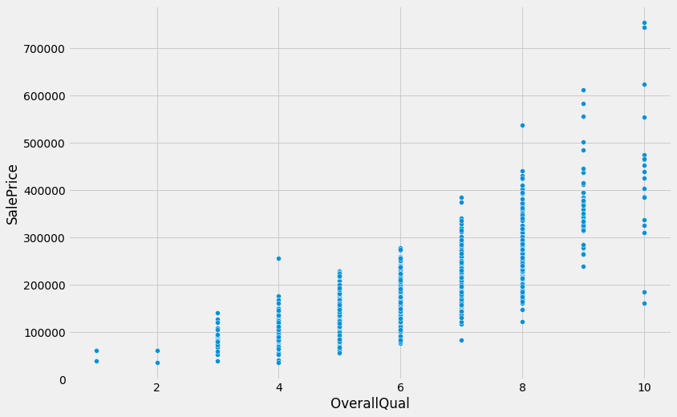

```python
customized_scatterplot(train.SalePrice, train.OverallQual)
```

Because OverallQual is categorical variable, so scatter plot is not suitable. But it is certain that there is a relationship between the two variables.  
Let's check other variables.

#### SalePrice vs GvLivArea

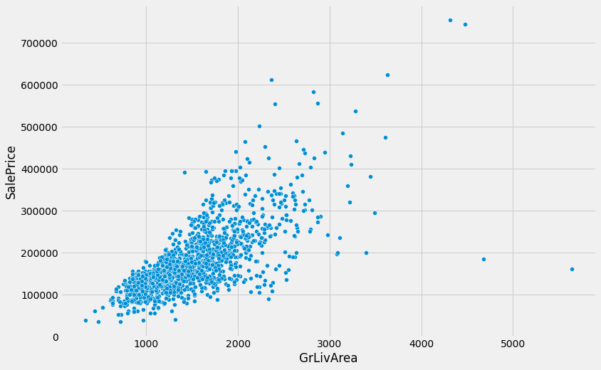

```python
customized_scatterplot(train.SalePrice, train.GrLivArea)
```

#### SalePrice vs GarageArea

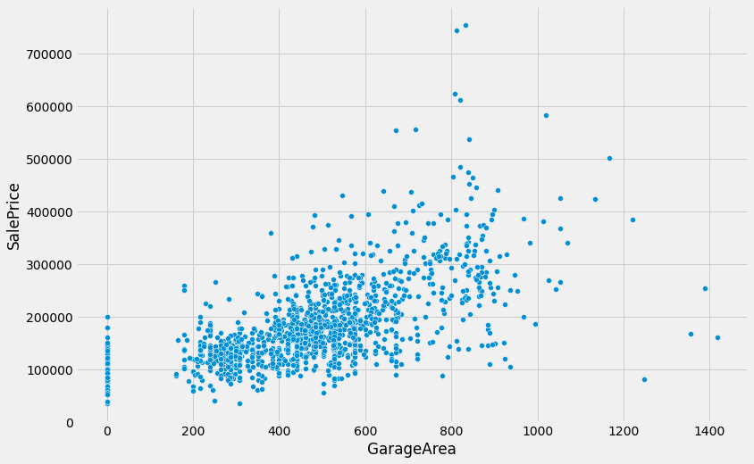

```python
customized_scatterplot(train.SalePrice, train.GarageArea)
```

#### SalePrice vs TotalBsmtSF

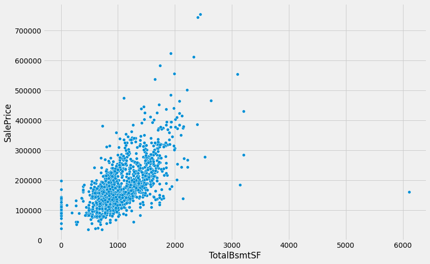

```python
customized_scatterplot(train.SalePrice, train.TotalBsmtSF)
```

#### SalePrice vs 1stFlrSF

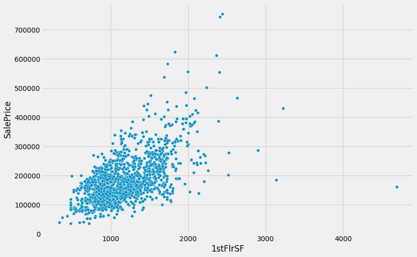

```python
customized_scatterplot(train.SalePrice, train['1stFlrSF'])
```

#### SalePrice vs MasVnrArea

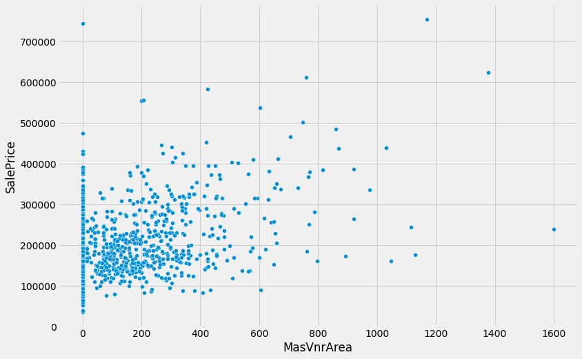

```python
customized_scatterplot(train.SalePrice, train.MasVnrArea)
```

There are multiple outliers in some figures. We'll address this problem later.

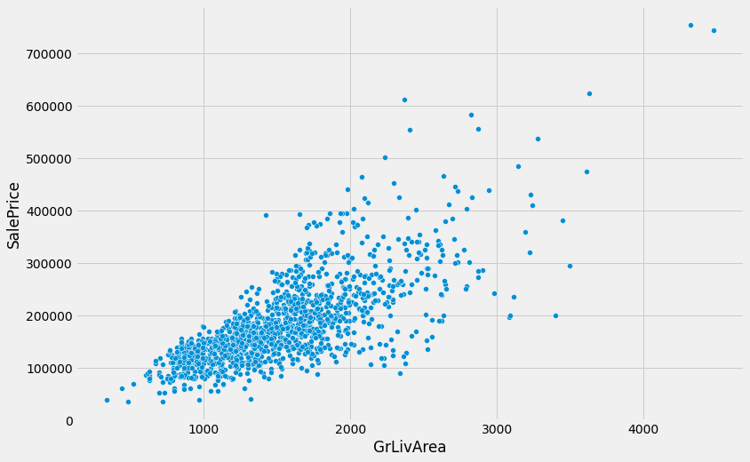

```python
train_ = train[train.GrLivArea < 4500]
train_.reset_index(drop = True, inplace = True)
previous_train = train_.copy()
customized_scatterplot(train_.SalePrice, train_.GrLivArea)
```

The two on the top-right edge of above figure seem to follow a trend, which can be explained by saying that "As the prices increased, this did too", so we leave this.

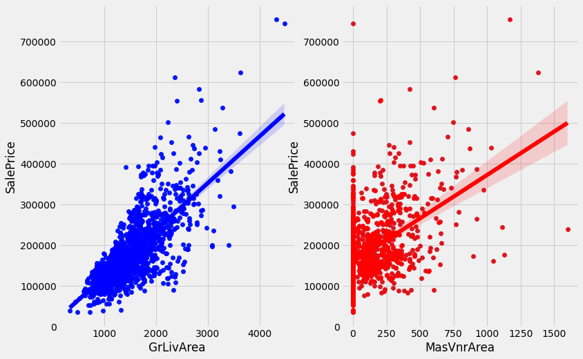

```python
fig, (ax1, ax2) = plt.subplots(figsize = (12, 8), ncols = 2, sharey = False)
sns.scatterplot(x = train_.GrLivArea, y = train_.SalePrice, ax = ax1);
sns.regplot(x = train_.GrLivArea, y = train_.SalePrice, ax = ax1, color = 'b');

sns.scatterplot(x = train_.MasVnrArea, y = train_.SalePrice, ax = ax2);
sns.regplot(x = train_.MasVnrArea, y = train_.SalePrice, ax = ax2, color = 'r');
```

**Residual plot** tell us how is the error variance across the true line.

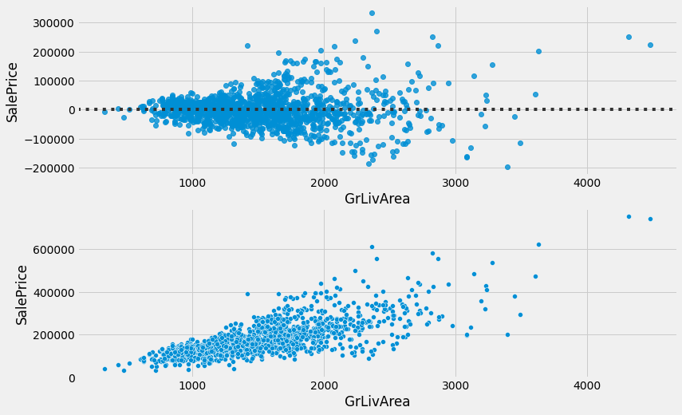

```python
fig,(ax1,ax2)=plt.subplots(figsize = (12, 8),ncols=1,nrows=2)
sns.residplot(train_.GrLivArea, train_.SalePrice, ax=ax1);
sns.scatterplot(train_.GrLivArea, train_.SalePrice ,ax=ax2);
```

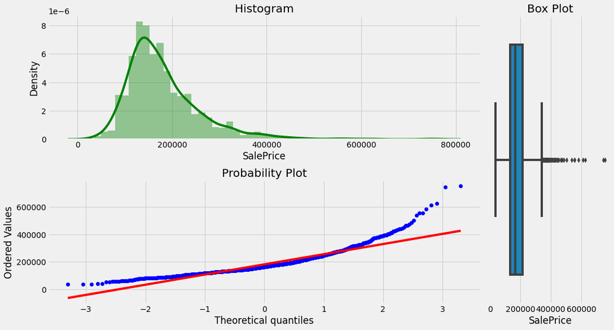

```python
plotting_3_chart(train_, 'SalePrice')
```

The reason why outliers was removed was because linear regression analysis was susceptible to outliers.  
Also, linear regression analysis requires normality. Therefore, we will apply the **log function** to solve these problems.

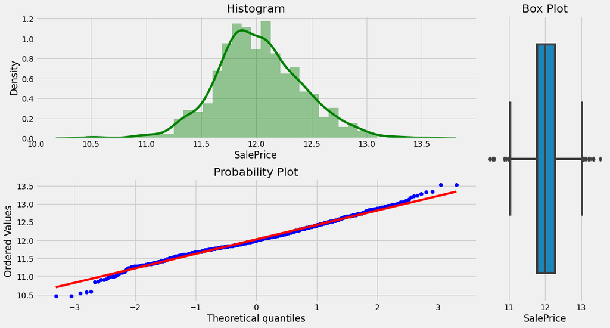

```python
train_['SalePrice'] = np.log1p(train_['SalePrice'])
plotting_3_chart(train_, 'SalePrice')
```

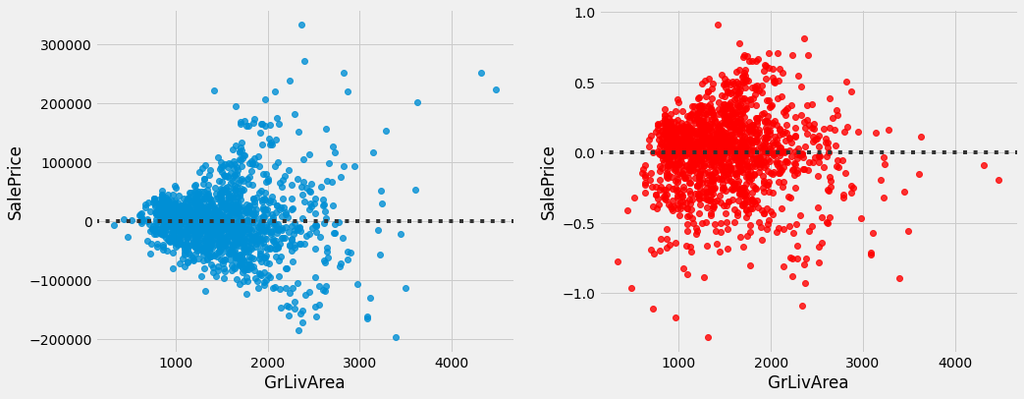

```python
fig, (ax1, ax2) = plt.subplots(figsize = (15, 6), ncols = 2, sharey = False, sharex = False)
sns.residplot(x = previous_train.GrLivArea, y = previous_train.SalePrice, ax = ax1);
sns.residplot(x = train_.GrLivArea, y = train_.SalePrice, ax = ax2, color = 'r');
```

Wow!  
Here, we can see that the pre-transformed chart on the left has heteroscedasticity, and the post-transformed chart on the right has homoscedasticity(almost an equal amount of variance across the zero lines).

But problem still remains. The name is **multicollinearity**.  
Multicollinearity is occur when there is a strong correlation between independent variables. Linear regression or multilinear regression requires independent variables to have little or no related features.If there is multicollinearity, the accuracy of analysis will be reduced.  
So we use Heatmap. this is an excellent way to identify whether there is multicollinearity or not. The best way to solve multicollinearity is to use regularization methods like Ridge or Lasso.

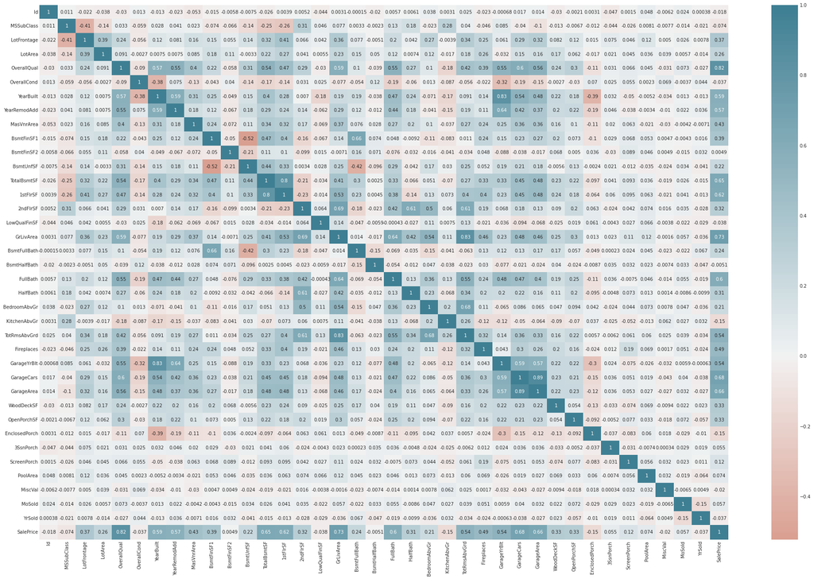

```python
style.use('ggplot')
sns.set_style('whitegrid')
plt.subplots(figsize = (30, 20))

# mask = np.zeros_like(train_.corr(), dtype = np.bool)
# mask[np.triu_indices_from(mask)] = True

sns.heatmap(train_.corr(),
            cmap = sns.diverging_palette(20, 220, n = 200),

            annot = True,
            center = 0);
```

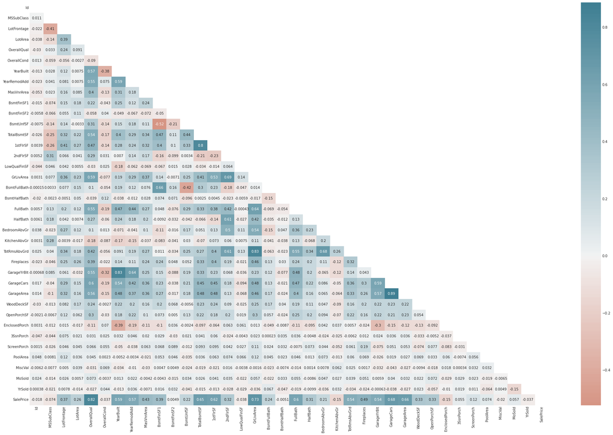

```python
style.use('ggplot')
sns.set_style('whitegrid')
plt.subplots(figsize = (30, 20))

mask = np.zeros_like(train_.corr(), dtype = np.bool)
mask[np.triu_indices_from(mask)] = True

sns.heatmap(train_.corr(),
            cmap = sns.diverging_palette(20, 220, n = 200),
            mask = mask,
            annot = True,
            center = 0);
```

But this time, we leave these variables for later study. There is algorithms as scikit-learn modules that can give us better outcome.

## Feature engineering

```python
train_.drop(columns = ['Id'], axis = 1, inplace = True)
test.drop(columns = ['Id'], axis = 1, inplace = True)
```

```python
#as y_train
y = train_['SalePrice'].reset_index(drop = True)
```

```python
previous_train = train_.copy()
```

```python
all_data = pd.concat((train_, test)).reset_index(drop = True)
all_data.drop(['SalePrice'], axis = 1, inplace = True)
```

### Dealing with Missing Values

```python
all_data.shape
```

```
(2917, 79)
```

```python
all_data.isnull().count().unique()
```

```
array([2917])
```

```python
ratio = (all_data.isnull().sum() / all_data.isnull().count()).sort_values(ascending = False)[(all_data.isnull().sum() / all_data.isnull().count()).sort_values(ascending = False) != 0]
total = all_data.isnull().sum().sort_values(ascending = False)[all_data.isnull().sum().sort_values(ascending = False) != 0]
concat_ = pd.concat([total, ratio], axis = 1, keys = ['Total', 'Ratio'])
concat_
```

|  | Total | Ratio |
| --- | --- | --- |
| PoolQC | 2908 | 0.996915 |
| MiscFeature | 2812 | 0.964004 |
| Alley | 2719 | 0.932122 |
| Fence | 2346 | 0.804251 |
| FireplaceQu | 1420 | 0.486802 |
| LotFrontage | 486 | 0.166610 |
| GarageCond | 159 | 0.054508 |
| GarageQual | 159 | 0.054508 |
| GarageYrBlt | 159 | 0.054508 |
| GarageFinish | 159 | 0.054508 |
| GarageType | 157 | 0.053822 |
| BsmtCond | 82 | 0.028111 |
| BsmtExposure | 82 | 0.028111 |
| BsmtQual | 81 | 0.027768 |
| BsmtFinType2 | 80 | 0.027425 |
| BsmtFinType1 | 79 | 0.027083 |
| MasVnrType | 24 | 0.008228 |
| MasVnrArea | 23 | 0.007885 |
| MSZoning | 4 | 0.001371 |
| BsmtHalfBath | 2 | 0.000686 |
| Utilities | 2 | 0.000686 |
| Functional | 2 | 0.000686 |
| BsmtFullBath | 2 | 0.000686 |
| BsmtFinSF2 | 1 | 0.000343 |
| BsmtFinSF1 | 1 | 0.000343 |
| Exterior2nd | 1 | 0.000343 |
| BsmtUnfSF | 1 | 0.000343 |
| TotalBsmtSF | 1 | 0.000343 |
| Exterior1st | 1 | 0.000343 |
| SaleType | 1 | 0.000343 |
| Electrical | 1 | 0.000343 |
| KitchenQual | 1 | 0.000343 |
| GarageArea | 1 | 0.000343 |
| GarageCars | 1 | 0.000343 |

```python
all_data['LotFrontage'] = all_data.groupby('Neighborhood')['LotFrontage'].transform(lambda x: x.fillna(x.mean()))
```

```python
all_data['LotFrontage'].head()
all_data['Neighborhood'].head()
```

```
0    CollgCr
1    Veenker
2    CollgCr
3    Crawfor
4    NoRidge
Name: Neighborhood, dtype: object
```

```python
# object columns
missing_val_col = ["Alley",
                   "PoolQC",
                   "MiscFeature",
                   "Fence",
                   "FireplaceQu",
                   "GarageType",
                   "GarageFinish",
                   "GarageQual",
                   "GarageCond",
                   'BsmtQual',
                   'BsmtCond',
                   'BsmtExposure',
                   'BsmtFinType1',
                   'BsmtFinType2',
                   'MasVnrType']

for i in missing_val_col:
    all_data[i] = all_data[i].fillna('None')
```

```python
# non-object columns
missing_val_col2 = ['BsmtFinSF1',
                    'BsmtFinSF2',
                    'BsmtUnfSF',
                    'TotalBsmtSF',
                    'BsmtFullBath',
                    'BsmtHalfBath',
                    'GarageYrBlt',
                    'GarageArea',
                    'GarageCars',
                    'MasVnrArea']

for i in missing_val_col2:
    all_data[i] = all_data[i].fillna(0)
```

```python
# all_data['MSSubClass'].dtype
all_data['MSSubClass'].head()
```

```
0    60
1    20
2    60
3    70
4    60
Name: MSSubClass, dtype: int64
```

```python
all_data['MSSubClass'] = all_data['MSSubClass'].astype(str)

#The mode function returns 'pandas.Series'. Therefore, we use [0] to extract the element.
all_data['MSZoning'] = all_data.groupby('MSSubClass')['MSZoning'].transform(lambda x: x.fillna(x.mode()[0]))
```

```python
all_data['Functional'] = all_data['Functional'].fillna(all_data['Functional'].mode()[0])
all_data['Utilities'] = all_data['Utilities'].fillna(all_data['Utilities'].mode()[0])
all_data['Exterior2nd'] = all_data['Exterior2nd'].fillna(all_data['Exterior2nd'].mode()[0])
all_data['KitchenQual'] = all_data['KitchenQual'].fillna(all_data['KitchenQual'].mode()[0])
all_data['Electrical'] = all_data['Electrical'].fillna(all_data['Electrical'].mode()[0])
all_data['SaleType'] = all_data['SaleType'].fillna(all_data['SaleType'].mode()[0])
all_data['Exterior1st'] = all_data['Exterior1st'].fillna(all_data['Exterior1st'].mode()[0])
```

```python
# all_data['YearBuilt'] = all_data['YearBuilt'].astype(str)
# all_data['YearRemodAdd'] = all_data['YearRemodAdd'].astype(str)
# all_data['GarageYrBlt'] = all_data['GarageYrBlt'].astype(str)
```

```python
if len(all_data.isnull().sum().sort_values(ascending = False)[all_data.isnull().sum().sort_values(ascending = False) != 0]) == 0:
    print('there is no null')
```

```
there is no null
```

```python
numeric_features = all_data.dtypes[all_data.dtypes != "object"].index
skewed_features = all_data[numeric_features].apply(lambda x: skew(x)).sort_values(ascending = False)
skewed_features
```

```
MiscVal          21.939672
PoolArea         17.688664
LotArea          13.109495
LowQualFinSF     12.084539
3SsnPorch        11.372080
KitchenAbvGr      4.300550
BsmtFinSF2        4.144503
EnclosedPorch     4.002344
ScreenPorch       3.945101
BsmtHalfBath      3.929996
MasVnrArea        2.621719
OpenPorchSF       2.529358
WoodDeckSF        1.844792
1stFlrSF          1.257286
GrLivArea         1.068750
LotFrontage       1.058803
BsmtFinSF1        0.980645
BsmtUnfSF         0.919688
2ndFlrSF          0.861556
TotRmsAbvGrd      0.749232
Fireplaces        0.725278
HalfBath          0.696666
TotalBsmtSF       0.671751
BsmtFullBath      0.622415
OverallCond       0.569314
BedroomAbvGr      0.326568
GarageArea        0.216857
MoSold            0.197345
OverallQual       0.189591
FullBath          0.165514
YrSold            0.131996
GarageCars       -0.219297
YearRemodAdd     -0.450134
YearBuilt        -0.599194
GarageYrBlt      -3.904632
dtype: float64
```

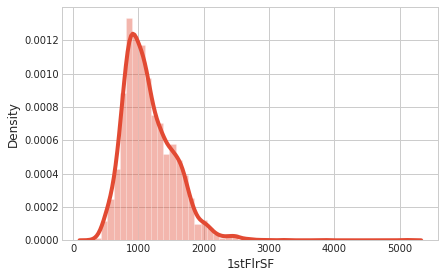

```python
sns.distplot(all_data['1stFlrSF']);
```

```python
## Fixing skewed features using boxcox transformation
def fixing_skewness(df):
    numeric_features = df.dtypes[df.dtypes != 'object'].index

    skewed_features = df[numeric_features].apply(lambda x: skew(x)).sort_values(ascending = False)
    high_skew = skewed_features[abs(skewed_features) > 0.5] #abs means absolute value
    skewed_features = high_skew.index

    for feature in skewed_features:
        df[feature] = boxcox1p(df[feature], boxcox_normmax(df[feature] + 1))

fixing_skewness(all_data)
```

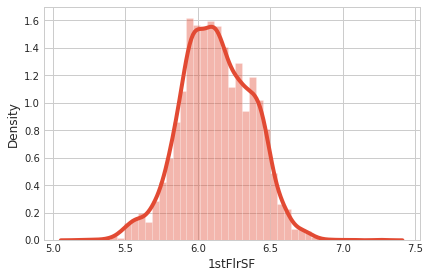

```python
sns.distplot(all_data['1stFlrSF']);
```

Compare to the above figure, we can see that skewness has been solved!

### Creating New Features

```python
all_data['TotalSF'] = (all_data['TotalBsmtSF']
                       + all_data['1stFlrSF']
                       + all_data['2ndFlrSF'])

all_data['YrBltAndRemod'] = all_data['YearBuilt'] + all_data['YearRemodAdd']

all_data['Total_sqr_footage'] = (all_data['BsmtFinSF1']
                                 + all_data['BsmtFinSF2']
                                 + all_data['1stFlrSF']
                                 + all_data['2ndFlrSF']
                                )


all_data['Total_Bathrooms'] = (all_data['FullBath']
                               + (0.5 * all_data['HalfBath'])
                               + all_data['BsmtFullBath']
                               + (0.5 * all_data['BsmtHalfBath'])
                              )


all_data['Total_porch_sf'] = (all_data['OpenPorchSF']
                              + all_data['3SsnPorch']
                              + all_data['EnclosedPorch']
                              + all_data['ScreenPorch']
                              + all_data['WoodDeckSF']
                             )
```

```python
all_data['hasapool'] = all_data['PoolArea'].apply(lambda x: 1 if x > 0 else 0)
all_data['has2ndfloor'] = all_data['2ndFlrSF'].apply(lambda x: 1 if x > 0 else 0)
all_data['hasgarage'] = all_data['GarageArea'].apply(lambda x: 1 if x > 0 else 0)
all_data['hasbsmt'] = all_data['TotalBsmtSF'].apply(lambda x: 1 if x > 0 else 0)
all_data['hasfireplace'] = all_data['Fireplaces'].apply(lambda x: 1 if x > 0 else 0)
```

```python
all_data.shape
```

```
(2917, 89)
```

### unnecessary feature drop

```python
drop_features = []
for i in all_data.columns:
    counts = all_data[i].value_counts(ascending = False)
    zeros = counts.iloc[0]
    # print(counts)
    if zeros / len(all_data) > 0.995:
        print(i,)
        drop_features.append(i)
```

```
Street
Utilities
PoolArea
PoolQC
hasapool
```

```python
all_data = all_data.drop(drop_features, axis = 1)
```

```python
all_data.shape
```

```
(2917, 84)
```

```python
feature_candidates = pd.get_dummies(all_data).reset_index(drop = True)
print(feature_candidates.head(5))
# print(feature_candidates.columns)
```

```
   LotFrontage    LotArea  ...  SaleCondition_Normal  SaleCondition_Partial
0    18.780786  13.833054  ...                     1                      0
1    21.443061  14.117918  ...                     1                      0
2    19.331294  14.476512  ...                     1                      0
3    17.840337  14.106196  ...                     0                      0
4    22.118472  15.022008  ...                     1                      0

[5 rows x 316 columns]
```

```python
X = feature_candidates.iloc[:len(y), :]
X_sub = feature_candidates.iloc[len(y):, :]
```

```python
print(X.shape, X_sub.shape)
```

```
(1458, 316) (1459, 316)
```

```python
def overfit_reducer(df):
    """
    This function takes in a dataframe and returns a list of features that are overfitted.
    """
    overfit = []
    for i in df.columns:
        counts = df[i].value_counts()
        zeros = counts.iloc[0]
        if zeros / len(df) * 100 > 99.94:
            overfit.append(i)
    overfit = list(overfit)
    return overfit


overfitted_features = overfit_reducer(X)
overfitted_features
```

```
[]
```

```python
X = X.drop(overfitted_features, axis=1)
X_sub = X_sub.drop(overfitted_features, axis=1)
```

```python
X.shape, y.shape, X_sub.shape
```

[output not shown]

```python
X_train, X_test, y_train, y_test = train_test_split(X, y, test_size = .33, random_state = 0)
X_train.shape, X_test.shape, y_train.shape, y_test.shape
```

[output not shown]

## Modeling the Data

First, let's check the variance of SalePrice and GrLivArea, these are correlated with each other as you can see above.

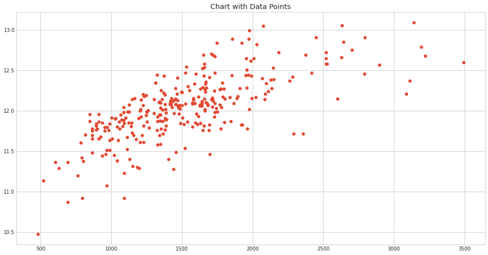

```python
sample_train = previous_train.sample(300)
# print(sample_train)

plt.subplots(figsize = (15, 8))
ax = plt.gca()
ax.scatter(sample_train.GrLivArea.values, sample_train.SalePrice.values);
plt.title('Chart with Data Points');
```

What happens if we take the average of the data points?

```python
type(sample_train.GrLivArea.values)
```

```
numpy.ndarray
```

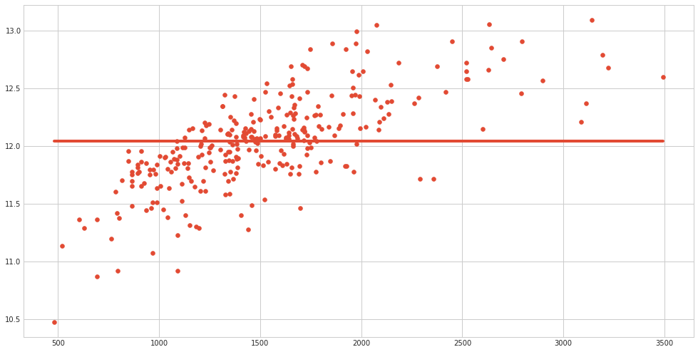

```python
plt.subplots(figsize = (15, 8))
ax = plt.gca()
ax.scatter(sample_train.GrLivArea.values, sample_train.SalePrice.values);
ax.plot((sample_train.GrLivArea.values.min(), sample_train.GrLivArea.values.max()), (sample_train.SalePrice.values.mean(), sample_train.SalePrice.values.mean()));
```

This way is the most efficient way to estimate the price of houses. But this doesn't represent all datapoint trend.  
So, we use **MSE**.

```python
sample_train['mean_sale_price'] = sample_train.SalePrice.mean()
sample_train['mse'] = np.square(sample_train.mean_sale_price - sample_train.SalePrice)
sample_train.mse.mean()# this is mse. the closer this value of MSE is to 0, the better.
```

```
0.1605016161860776
```

The detail of MSE is [here](https://towardsdatascience.com/https-medium-com-chayankathuria-regression-why-mean-square-error-a8cad2a1c96f).  
In a nutshell, the closer the value of MSE is to "0", the better. We want to minimize this error. In the process of reducing MSE, we use the powerful model, **Linear Regression**.

$$ y = \beta_0 + \beta_1 x + \epsilon \\ $$

$$ \hat{\beta}_1 = r_{xy} \frac{s_y}{s_x}$$
$$ \hat{\beta}_0 = \bar{y} - \hat{\beta}_1 \bar{x} $$
$$ r_{xy}= \frac{\sum{(x_i - \bar{x})(y_i - \bar{y})}}{\sqrt{\sum(x_i - \bar{x})^2{\sum(y_i - \bar{y})^2}}}$$
Here...

- $\bar{y}$ : the sample mean of observed values $Y$
- $\bar{x}$ : the sample mean of observed values $X$
- $s_y$ : the sample standard deviation of observed values $Y$
- $s_x$ : the sample standard deviation of observed values $X$
- $ \epsilon$ : error or residual. In above figure, the distance of datapoint and redline.

```python
y_bar = sample_train.SalePrice.mean()
x_bar = sample_train.GrLivArea.mean()
std_y = sample_train.SalePrice.std()
std_x = sample_train.GrLivArea.std()
r_xy = sample_train.corr().loc['GrLivArea', 'SalePrice']#pearson correlation coefficient 相関係数
```

```python
beta_1 = r_xy * (std_y / std_x)
beta_0 = y_bar - beta_1 * x_bar

sample_train['Linear_Yhat'] = beta_0 + beta_1 * sample_train['GrLivArea']
```

```python
sample_train.head(10)
```

|  | MSSubClass | MSZoning | LotFrontage | LotArea | Street | Alley | LotShape | LandContour | Utilities | LotConfig | LandSlope | Neighborhood | Condition1 | Condition2 | BldgType | HouseStyle | OverallQual | OverallCond | YearBuilt | YearRemodAdd | RoofStyle | RoofMatl | Exterior1st | Exterior2nd | MasVnrType | MasVnrArea | ExterQual | ExterCond | Foundation | … |
| --- | --- | --- | --- | --- | --- | --- | --- | --- | --- | --- | --- | --- | --- | --- | --- | --- | --- | --- | --- | --- | --- | --- | --- | --- | --- | --- | --- | --- | --- | --- |
| 908 | 60 | RL | 149.0 | 12589 | Pave | NaN | IR2 | Lvl | AllPub | Inside | Gtl | Gilbert | Norm | Norm | 1Fam | 2Story | 6 | 5 | 2005 | 2005 | Gable | CompShg | VinylSd | VinylSd | None | 0.0 | Gd | TA | PConc | … |
| 936 | 60 | RL | 75.0 | 9675 | Pave | NaN | Reg | Lvl | AllPub | Inside | Gtl | Somerst | Norm | Norm | 1Fam | 2Story | 7 | 5 | 2005 | 2005 | Gable | CompShg | VinylSd | VinylSd | None | 0.0 | Gd | TA | PConc | … |
| 1114 | 20 | RL | 93.0 | 12085 | Pave | NaN | Reg | Lvl | AllPub | Inside | Gtl | NridgHt | Norm | Norm | 1Fam | 1Story | 8 | 5 | 2007 | 2007 | Hip | CompShg | VinylSd | VinylSd | Stone | 328.0 | Gd | TA | PConc | … |
| 231 | 60 | RL | 174.0 | 15138 | Pave | NaN | IR1 | Lvl | AllPub | Inside | Gtl | NoRidge | Norm | Norm | 1Fam | 2Story | 8 | 5 | 1995 | 1996 | Gable | CompShg | VinylSd | VinylSd | BrkFace | 506.0 | Gd | TA | PConc | … |
| 1356 | 160 | FV | NaN | 2117 | Pave | NaN | Reg | Lvl | AllPub | Inside | Gtl | Somerst | Norm | Norm | Twnhs | 2Story | 6 | 5 | 2000 | 2000 | Gable | CompShg | MetalSd | MetalSd | BrkFace | 216.0 | Gd | TA | PConc | … |
| 686 | 160 | FV | NaN | 5105 | Pave | NaN | IR2 | Lvl | AllPub | FR2 | Gtl | Somerst | Norm | Norm | TwnhsE | 2Story | 7 | 5 | 2004 | 2004 | Gable | CompShg | MetalSd | MetalSd | None | 0.0 | Gd | TA | PConc | … |
| 798 | 50 | RL | 60.0 | 7200 | Pave | NaN | Reg | Lvl | AllPub | Corner | Gtl | SWISU | Feedr | Norm | 1Fam | 1.5Fin | 5 | 7 | 1937 | 1950 | Gable | CompShg | Wd Sdng | Wd Sdng | BrkFace | 252.0 | TA | TA | BrkTil | … |
| 540 | 60 | RL | NaN | 11000 | Pave | NaN | Reg | Lvl | AllPub | FR2 | Gtl | NoRidge | Norm | Norm | 1Fam | 2Story | 8 | 5 | 2000 | 2000 | Gable | CompShg | VinylSd | VinylSd | BrkFace | 72.0 | Gd | TA | PConc | … |
| 1023 | 20 | RL | NaN | 15498 | Pave | NaN | IR1 | Lvl | AllPub | Corner | Gtl | Timber | Norm | Norm | 1Fam | 1Story | 8 | 6 | 1976 | 1976 | Hip | WdShake | Stone | HdBoard | None | 0.0 | Gd | TA | CBlock | … |
| 230 | 20 | RL | 73.0 | 8760 | Pave | NaN | Reg | Lvl | AllPub | Inside | Gtl | NAmes | Norm | Norm | 1Fam | 1Story | 6 | 6 | 1959 | 1959 | Hip | CompShg | MetalSd | MetalSd | BrkFace | 220.0 | TA | TA | CBlock | … |

10 rows × 83 columns

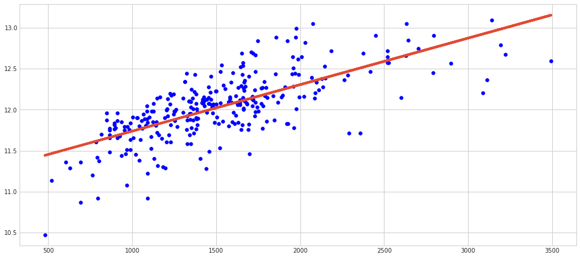

```python
fig = plt.figure(figsize = (15, 7))
ax = plt.gca()

ax.scatter(sample_train.GrLivArea, sample_train.SalePrice, c = 'b');
ax.plot(sample_train.GrLivArea, sample_train.Linear_Yhat);
```

```python
print('mean squared error for regression line is {}'.format(np.square(sample_train['SalePrice'] - sample_train['Linear_Yhat']).mean()))
# print('mean squared error for regression line is {}'.format(mean_squared_error(sample_train['SalePrice'], sample_train['Linear_Yhat'])))
```

```
mean squared error for regression line is 0.07903865432556188
```

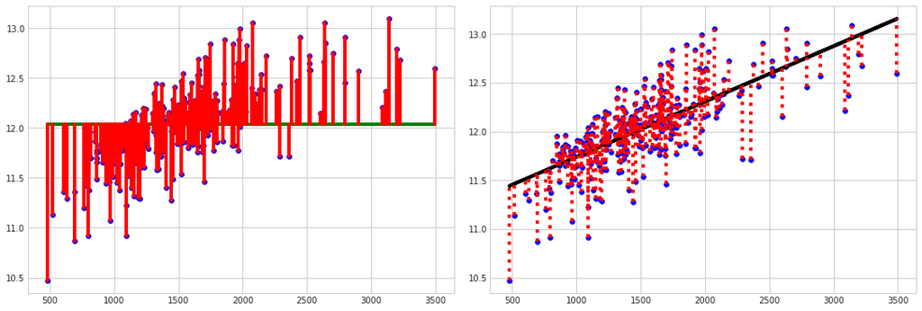

```python
fig = plt.figure(constrained_layout = True, figsize = (15, 5))
grid = gridspec.GridSpec(ncols = 2, nrows = 1, figure = fig)
ax1 = fig.add_subplot(grid[0, :1])

# ax1 = fig.gca()
ax1.scatter(x = sample_train['GrLivArea'], y = sample_train['SalePrice'], c = 'b');
ax1.plot(sample_train['GrLivArea'], sample_train['mean_sale_price'], color = 'g');

for _, row in sample_train.iterrows():

    plt.plot((row['GrLivArea'], row['GrLivArea']), (row['SalePrice'], row['mean_sale_price']), 'r-')


ax2 = fig.add_subplot(grid[0, 1:])
ax2.scatter(x = sample_train['GrLivArea'], y = sample_train['SalePrice'], c = 'b');
ax2.plot(sample_train['GrLivArea'], sample_train['Linear_Yhat'], color = 'k');

for _, row in sample_train.iterrows():
    plt.plot((row['GrLivArea'], row['GrLivArea']), (row['SalePrice'], row['Linear_Yhat']), 'r:')
```

```python
lin_reg = LinearRegression(normalize = True, n_jobs = -1)
lin_reg.fit(X_train, y_train)
y_pred = lin_reg.predict(X_test)
```

```python
print('%.2f'%mean_squared_error(y_test, y_pred))
```

```
6912297519104760832.00
```

```python
lin_reg = LinearRegression()
cv = KFold(shuffle = True, random_state = 2, n_splits = 10)
scores = cross_val_score(lin_reg, X, y, cv = cv, scoring = 'neg_mean_absolute_error')
```

```python
print('%.8f'%scores.mean())
print(scores)
```

```
-0.23719096
[-0.24678387 -0.27597403 -0.23538111 -0.24424397 -0.24604498 -0.25990636
 -0.20972187 -0.1998141  -0.21750047 -0.23653887]
```

Above we've seen is the simplest way to construct the model. However, there are more complex regression, so let's dive deep into some of it.

## Regularization Models

What makes regressionmodel more effective is its ability of regularizing. *Regularization* is the ability to structurally prevent overfitting by imposing a penalty on the coefficients.

There are three types of regularizations.

- Ridge
- Lasso
- Elastic Net

### $$ \text{minimize:}\; RSS+Ridge = \sum_{i=1}^n \left(y_i - \left(\beta_0 + \sum_{j=1}^p\beta_j x_j\right)\right)^2 + \lambda_2\sum_{j=1}^p \beta_j^2$$

One of the benefits of regularization of using *Ridge* is that it deals with **multicollinearity**(high correlation between predictor variables) well especially.  
(Lasso deals with multicollinearity more brutally by penalizing related coefficient and force them to become zero, hence removing them.)  
We have some points we need to be aware of.

- It is essential to standardize the predictor variables before constructing the models.
- It is important to chec for multicollinearity.

```python
alpha_ridge = [-3,-2,-1,1e-15, 1e-10, 1e-8,1e-5,1e-4, 1e-3,1e-2,0.5,1,1.5, 2,3,4, 5, 10, 20, 30, 40]
temp_rss = {}
temp_mse = {}

for i in alpha_ridge:
    ridge = Ridge(alpha = i, normalize = True)
    ridge.fit(X_train, y_train)
    y_pred = ridge.predict(X_test)

    mse = mean_squared_error(y_test, y_pred)
    temp_mse[i] = mse

    rss = sum((y_pred - y_test) ** 2)
    temp_rss[i] = rss
```

```python
for key, value in sorted(temp_rss.items(), key = lambda item: item[1]):
    print("%s: %s" % (key, value))
```

```
0.5: 6.582085537597893
1: 7.070555616953949
0.01: 7.3860496209282935
1.5: 7.638565827338896
0.001: 8.136290311592008
2: 8.229614850028353
0.0001: 8.404872469620711
1e-05: 8.439327380507988
1e-08: 8.443261124572093
1e-10: 8.443264150905977
1e-15: 8.44340684601971
3: 9.441436166518342
4: 10.672292658717058
5: 11.908651693896914
10: 17.90946139601968
20: 28.002370997787523
30: 35.5853900089752
40: 41.330499920903414
-2: 672.6856771141377
-1: 6660.512316384364
-3: 95541.44050025904
```

```python
for key, value in sorted(temp_mse.items(), key = lambda item: item[1]):
    print("%s: %s" % (key, value))
```

```
0.5: 0.013655779123647073
1: 0.014669202524800726
0.01: 0.01532375440026618
1.5: 0.015847646944686496
0.001: 0.016880270356000024
2: 0.017073889730349276
0.0001: 0.01743749475025044
1e-05: 0.017508977967858882
1e-08: 0.01751713926259772
1e-10: 0.017517145541298695
1e-15: 0.017517441589252516
3: 0.01958804183924969
4: 0.02214168601393581
5: 0.02470674625289816
10: 0.03715655891290393
20: 0.05809620538960067
30: 0.07382860997712701
40: 0.0857479251471025
-2: 1.3956134379961362
-1: 13.81849028295511
-3: 198.2187562246038
```

### $$ \text{minimize:}\; RSS + Lasso = \sum_{i=1}^n \left(y_i - \left(\beta_0 + \sum_{j=1}^p\beta_j x_j\right)\right)^2 + \lambda_1\sum_{j=1}^p |\beta_j|$$

```python
temp_rss_ = {}
temp_mse_ = {}

for i in alpha_ridge:
    lasso_reg = Lasso(alpha = i, normalize = True)
    lasso_reg.fit(X_train, y_train)
    y_pred = lasso_reg.predict(X_test)

    mse = mean_squared_error(y_test, y_pred)
    temp_mse_[i] = mse

    rss = sum((y_pred - y_test) ** 2)
    temp_rss_[i] = rss
```

```python
for key, value in sorted(temp_mse_.items(), key = lambda item: item[1]):
    print("%s: %s" % (key, value))
```

```
0.0001: 0.012299230954607582
1e-05: 0.014609263283665708
0.001: 0.017440792532148735
1e-15: 0.017493012818409506
1e-10: 0.017493090399749826
1e-08: 0.017495675675204266
0.01: 0.15818469608554872
0.5: 0.16467335518379542
1: 0.16467335518379542
1.5: 0.16467335518379542
2: 0.16467335518379542
3: 0.16467335518379542
4: 0.16467335518379542
5: 0.16467335518379542
10: 0.16467335518379542
20: 0.16467335518379542
30: 0.16467335518379542
40: 0.16467335518379542
-1: 6289358968.55829
-2: 25157442880.43014
-3: 56604251735.63294
```

```python
for key, value in sorted(temp_rss_.items(), key = lambda item: item[1]):
    print("%s: %s" % (key, value))
```

```
0.0001: 5.928229320120854
1e-05: 7.041664902726876
0.001: 8.40646200049569
1e-15: 8.431632178473382
1e-10: 8.43166957267941
1e-08: 8.432915675448461
0.01: 76.24502351323456
0.5: 79.37255719858955
1: 79.37255719858955
1.5: 79.37255719858955
2: 79.37255719858955
3: 79.37255719858955
4: 79.37255719858955
5: 79.37255719858955
10: 79.37255719858955
20: 79.37255719858955
30: 79.37255719858955
40: 79.37255719858955
-1: 3031471022845.094
-2: 12125887468367.324
-3: 27283249336575.08
```

### **Elastic Net**

Elastic Net is the combination of both Ridge and Lasso.

### $$ \text{minimize:}\; RSS + Ridge + Lasso = \sum_{i=1}^n \left(y_i - \left(\beta_0 + \sum_{j=1}^p\beta_j x_j\right)\right)^2 + \lambda_1\sum_{j=1}^p |\beta_j| + \lambda_2\sum_{j=1}^p \beta_j^2$$

```python
_temp_rss = {}
_temp_mse = {}

for i in alpha_ridge:
    lasso_reg = ElasticNet(alpha = i, normalize = True)
    lasso_reg.fit(X_train, y_train)
    y_pred = lasso_reg.predict(X_test)

    mse = mean_squared_error(y_test, y_pred)
    _temp_mse[i] = mse

    rss = sum((y_pred - y_test) ** 2)
    _temp_rss[i] = rss
```

```python
for key, value in sorted(_temp_mse.items(), key = lambda item: item[1]):
    print("%s: %s" % (key, value))
```

```
0.0001: 0.012598325594470118
1e-05: 0.014926102318142355
0.001: 0.015358826362484448
1e-08: 0.017490852814902928
1e-15: 0.01749301281767271
1e-10: 0.017493016735127744
0.01: 0.10668946201014728
0.5: 0.16467335518379542
1: 0.16467335518379542
1.5: 0.16467335518379542
2: 0.16467335518379542
3: 0.16467335518379542
4: 0.16467335518379542
5: 0.16467335518379542
10: 0.16467335518379542
20: 0.16467335518379542
30: 0.16467335518379542
40: 0.16467335518379542
-3: 5.719915734147129
-2: 5.805970605714971
-1: 6.076485793484611
```

```python
for key, value in sorted(_temp_rss.items(), key = lambda item: item[1]):
    print("%s: %s" % (key, value))
```

```
0.0001: 6.07239293653459
1e-05: 7.194381317344614
0.001: 7.402954306717513
1e-08: 8.43059105678321
1e-15: 8.431632178118246
1e-10: 8.431634066331574
0.01: 51.424320688891015
0.5: 79.37255719858955
1: 79.37255719858955
1.5: 79.37255719858955
2: 79.37255719858955
3: 79.37255719858955
4: 79.37255719858955
5: 79.37255719858955
10: 79.37255719858955
20: 79.37255719858955
30: 79.37255719858955
40: 79.37255719858955
-3: 2756.9993838589176
-2: 2798.477831954615
-1: 2928.8661524595814
```

```python
kfolds = KFold(n_splits = 10, shuffle = True, random_state = 42)
```

```python
ridge = make_pipeline(
                        RobustScaler(),
                      RidgeCV(alphas = (0.01, 1e-05, 1e-02), cv = kfolds)
                      )
#The larger the alphas, the stronger the regularization.
lasso = make_pipeline(
    RobustScaler(),
     LassoCV(max_iter = 1e7, alphas = (0.01, 1e-05, 1e-02), random_state = 42, cv = kfolds)
     )
elasticnet = make_pipeline(
    RobustScaler(),
    ElasticNetCV(max_iter = 1e7, alphas = (0.01, 0.01, 1), cv = kfolds)
    )
svr = make_pipeline(RobustScaler(), SVR(C = 20, epsilon = 0.008, gamma = 'auto'))
```

```python
gbr = GradientBoostingRegressor(n_estimators = 3000,
                                learning_rate = 0.05,
                                max_depth = 4,
                                max_features = 'sqrt',
                                min_samples_leaf = 15,
                                min_samples_split = 10,
                                loss = 'huber',
                                random_state = 42)
```

```python
lightgbm = LGBMRegressor(objective = 'regression',
                         num_leaves = 4,
                         learning_rate = 0.01,
                         n_estimators = 5000,
                         max_bin = 200,
                         bagging_fraction = 0.75,
                         bagging_freq = 5,
                         bagging_seed = 7,
                         feature_fraction = 0.2,
                         feature_fraction_seed = 7,
                         verbose = -1)
```

```python
xgboost = xg.XGBRegressor(learning_rate=0.01,n_estimators=3460,
                                     max_depth=3, min_child_weight=0,
                                     gamma=0, subsample=0.7,
                                     colsample_bytree=0.7,
                                     objective='reg:linear', nthread=-1,
                                     scale_pos_weight=1, seed=27,
                                     reg_alpha=0.00006)
```

```python
stack_gen = StackingCVRegressor(regressors = (ridge, lasso, elasticnet, lightgbm),
                                meta_regressor = lightgbm,
                                use_features_in_secondary = True)
```

```python
def rmsle(y, y_pred):
    return np.sqrt(mean_squared_error(y, y_pred))

def cv_rmse(model):
    rmse = np.sqrt(-cross_val_score(model, X_train, y_train, scoring = "neg_mean_squared_error", cv = kfolds))
    return rmse
```

```python
score = cv_rmse(ridge)
print("Ridge: {:.4f} ({:.4f})\n".format(score.mean(), score.std()))

score = cv_rmse(lasso)
print("Lasso: {:.4f} ({:.4f})\n".format(score.mean(), score.std()))

score = cv_rmse(elasticnet)
print("elastic net: {:.4f} ({:.4f})\n".format(score.mean(), score.std()))

score = cv_rmse(svr)
print("SVR: {:.4f} ({:.4f})\n".format(score.mean(), score.std()))

score = cv_rmse(lightgbm)
print("lightgbm: {:.4f} ({:.4f})\n".format(score.mean(), score.std()))

score = cv_rmse(gbr)
print("gradient_boosting_regressor: {:.4f} ({:.4f})".format(score.mean(), score.std()))

# score = cv_rmse(xgboost)
# print("xgboost: {:.4f} ({:.4f})\n".format(score.mean(), score.std()))

# score = cv_rmse(stack_gen)
# print("xgboost: {:.4f} ({:.4f})\n".format(score.mean(), score.std()))
```

[output not shown]

```python
elastic_model_full_data = elasticnet.fit(X_train, y_train)
lasso_model_full_data = lasso.fit(X_train, y_train)
ridge_model_full_data = ridge.fit(X_train, y_train)
svr_model_full_data = svr.fit(X_train, y_train)
lgb_model_full_data = lightgbm.fit(X_train, y_train)
# stack_gen_model = stack_gen.fit(np.array(X), np.array(y))
```

```python
# abc
```

```python
def blend_models_predict(X):
    return (
        (0.2 * elastic_model_full_data.predict(X)) + \
        (0.2 * lasso_model_full_data.predict(X)) + \
        (0.2 * ridge_model_full_data.predict(X)) + \
        (0.2 * svr_model_full_data.predict(X)) + \
        (0.2 * lgb_model_full_data.predict(X))# + \
#         (0.1 * stack_gen_model.predict(np.array(X)))
    )
```

```python
print("RMSLE score on train data: ", rmsle(y, blend_models_predict(X)))
```

```
RMSLE score on train data:  0.08391955725828769
```

```python
submission = pd.read_csv("/content/drive/MyDrive/Colab Notebooks/Kaggle_/Regression_/House_price/sample_submission.csv")
print(submission.shape)
submission.iloc[:, 1] = np.floor(np.expm1(blend_models_predict(X_sub)))
```

```
(1459, 2)
```

```python
submission.to_csv("submission.csv", index = False)
```

```python
submission
```

|  | Id | SalePrice |
| --- | --- | --- |
| 0 | 1461 | 126279.0 |
| 1 | 1462 | 160512.0 |
| 2 | 1463 | 189299.0 |
| 3 | 1464 | 196745.0 |
| 4 | 1465 | 189206.0 |
| ... | ... | ... |
| 1454 | 2915 | 84930.0 |
| 1455 | 2916 | 79925.0 |
| 1456 | 2917 | 176668.0 |
| 1457 | 2918 | 117823.0 |
| 1458 | 2919 | 217784.0 |

1459 rows × 2 columns

## Thank you!!!

If you find this notebook useful, please **upvote**!  
And if you have any questions, please ask on the **comments**!

## Other Work( please **upvote**＜( )＞ )

- [The power of normality and visualization](https://www.kaggle.com/fightingmuscle/the-power-of-normality-and-visualization)
- [【Over 0.8!】Titanic_more_technical_EDA(ENG&JPN)](https://www.kaggle.com/fightingmuscle/over-0-8-titanic-more-technical-eda-eng-jpn)

> These notebooks were put together by me as a beginner, so I believe anyone can learn from them!